# Teoria das Estruturas Aeroespaciais II

Flambagem de cilindros

Professor Luiz Carvalho - luizcarvalho@demec.ufmg.br

Universidade Federal de Minas Gerais (UFMG)

## Percurso da disciplina

01 · Introdução

02 · Métodos de otimização

03 · Método dos elementos finitos

04 · Método de densidades

05 · Restrições de tensão e flambagem

06 · Aplicações de otimização topológica

07 · Projeto de estruturas

## Equação de Donnell

Assim como em placas planas, a equação diferencial para os deslocamentos $w(x, y)$ pode ser obtida substituindo suas relações cinemáticas e constitutivas na equação de equilíbrio, mas incluindo agora uma curvatura $1/R$ do painel.

Para pequenas curvaturas relativas e considerando uma sistema de coordenadas $x$ longitudinal ao cilindro e $y$ ao longo da circunferência, podemos chegar na seguinte versão simplificada da equação de Donnell.

$$D \nabla^4 w + \frac{Et}{R^2} w + t \left( \sigma_x \frac{\partial^2 w}{\partial x^2} + 2 \tau \frac{\partial^2 w}{\partial x \partial y} + \sigma_y\frac{\partial^2 w}{\partial y^2} \right) + p = 0$$

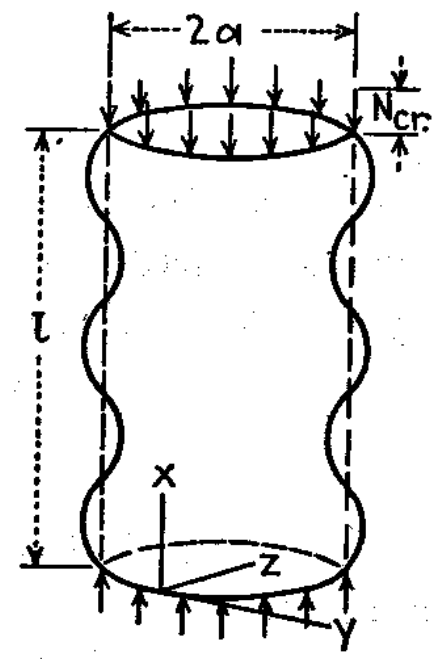

## Equação de Donnell

Podemos adotar condições de contorno como em placas nas suas bordas (para o caso bi-apoiado $w(0, y) = w(L, y) = 0$ e $w_{xx}|_{(0, y)} = w_{xx}|_{(L, y)} = 0$), mas periódicas ao longo da circunferência ($w(x, 0) = w(x, 2\pi R)$).

Para um cilindro simplemente apoiado, uma solução por série de Fourier pode ser assumida para o deslocamento transversal $w(x, y)$, assumindo um primeiro termo dominante da série, com $m$ meias-ondas ao longo do comprimento e $n$ meias-ondas ao longo da circunferência.

$$w(x, y) = w_0 \sin\left(\frac{m \pi x}{L}\right) \cos\left(\frac{n y}{R}\right)$$

**Para uma deflexão simétrica em relação ao eixo longitudinal:**

$$w(x) = w_0 \sin\left(\frac{m \pi x}{L}\right)$$

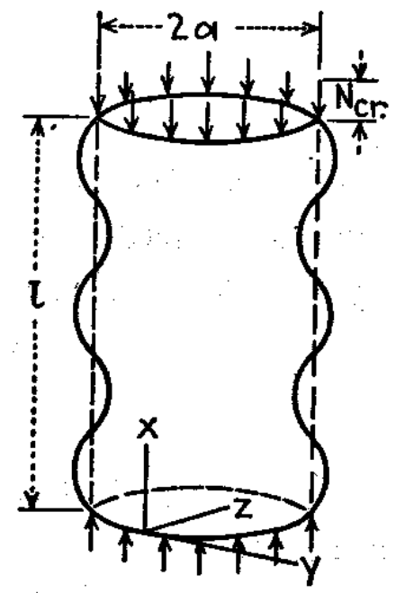

## Coeficiente de flambagem $k_c$

Substituindo a solução assumida na equação de Donnell, podemos obter uma expressão para a carga crítica de flambagem do cilindro simplesmente apoiado, nos moldes da obtida para placas:

$$\sigma_{cr} = \frac{k_c \pi^2 E}{12(1 - \nu^2)} \left(\frac{t}{L}\right)^2$$

O coeficiente de flambagem $k_c$ depende do modo de flambagem, $m$ e $n$ (contido no termo $\beta = n L / m \pi r$) e de parâmetros geométricos do cilindro contidos no termo $Z$ chamado parâmetro de Batdorf.

$$k_c = \frac{(m^2 + \beta^2)^2}{m^2} + \frac{12 Z^2m^2}{\pi^4 (m^2 + \beta^2)^2}$$

$$Z = \frac{L^2}{R t} \sqrt{1 - \nu^2}$$

Para o caso simplificado com deflexão axisimétrica, temos $n = 0$ e $\beta = 0$, e o coeficiente de flambagem se reduz a:

$$k_c = m^2 + \frac{12 Z^2}{\pi^4 m^2}$$

## Coeficiente de flambagem $k_c$

- (a)
- (b)

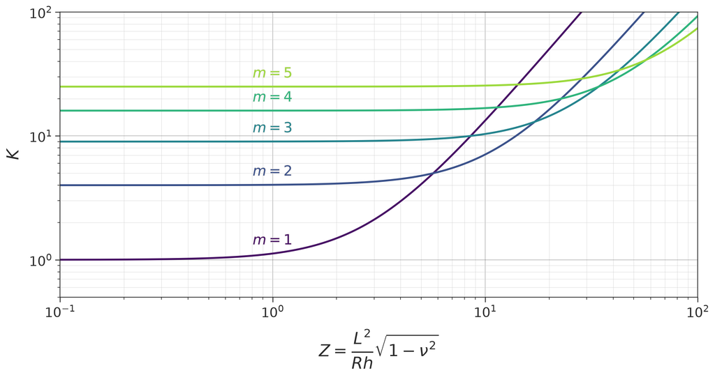

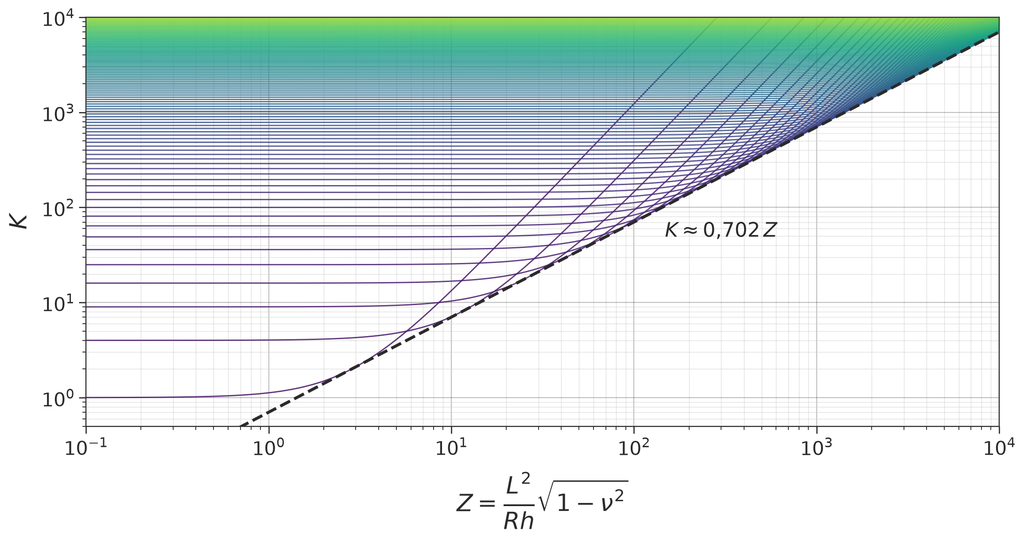

## Coeficiente de flambagem $k_c$

Assim como para placas, o coeficiente de flambagem a ser utilizado deve ser o da curva de menor valor dentre as famílias observadas anteriormente, para o valor de $Z$ do cilindro em questão, onde observa-se agora um comportamento linear para $k_c(Z)$.

O coeficiente de flambagem pode ser obtido a partir de um problema de otimização, minimizando a função $k_c(Z)$ em relação ao modo de flambagem, $m$ ou o termo completo $(m^2 + \beta^2)^2/m^2$. Fazendo $\partial k_c / \partial m = 0$ e substituindo na equação de $k_c$, obtêm-se:

$$k_c = \frac{4 \sqrt{3}}{\pi^2} Z \approx 0.702 Z$$

Este desenvolvimento assume um comportamento continuo de $m$, o que é uma aproximação razoável apenas para valores de $Z$ suficientemente grandes, como observado na região linear da curva de $k_c(Z)$ considerada a partir de $Z \geq 2,85$.

## Flambagem axial: envoltória dos modos

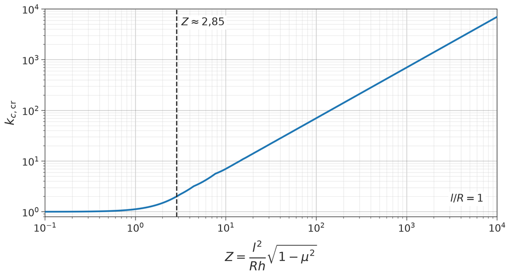

## Fator de knockdown

O modelo clássico considera uma casca perfeita. Para representar a redução da resistência observada experimentalmente, introduzimos um fator de knockdown, $\gamma$.

Para a compressão axial, adotamos a expressão empírica:

$$\gamma=1-0{,}901\left(1-e^{-\phi}\right)$$

com

$$\phi=\frac{1}{16}\sqrt{\frac{R}{t}},
\qquad \frac{R}{t}<1500.$$

Quanto maior a razão $R/t$, menor o fator $\gamma$ e maior a redução prevista em relação à solução clássica.

Na curva de coeficientes, aplicamos a correção por meio de $k_{c,\mathrm{corr}}=f(\gamma Z)$, sendo $k_{c,\mathrm{teo}}=f(Z)$.

- Bhrun
- Fator de *knockdown*

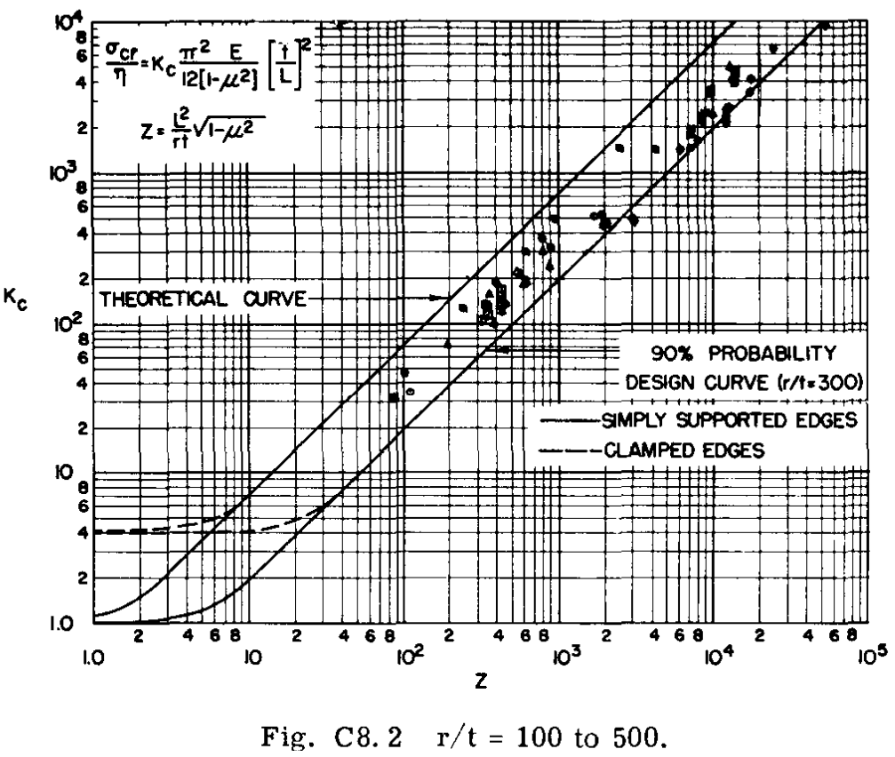

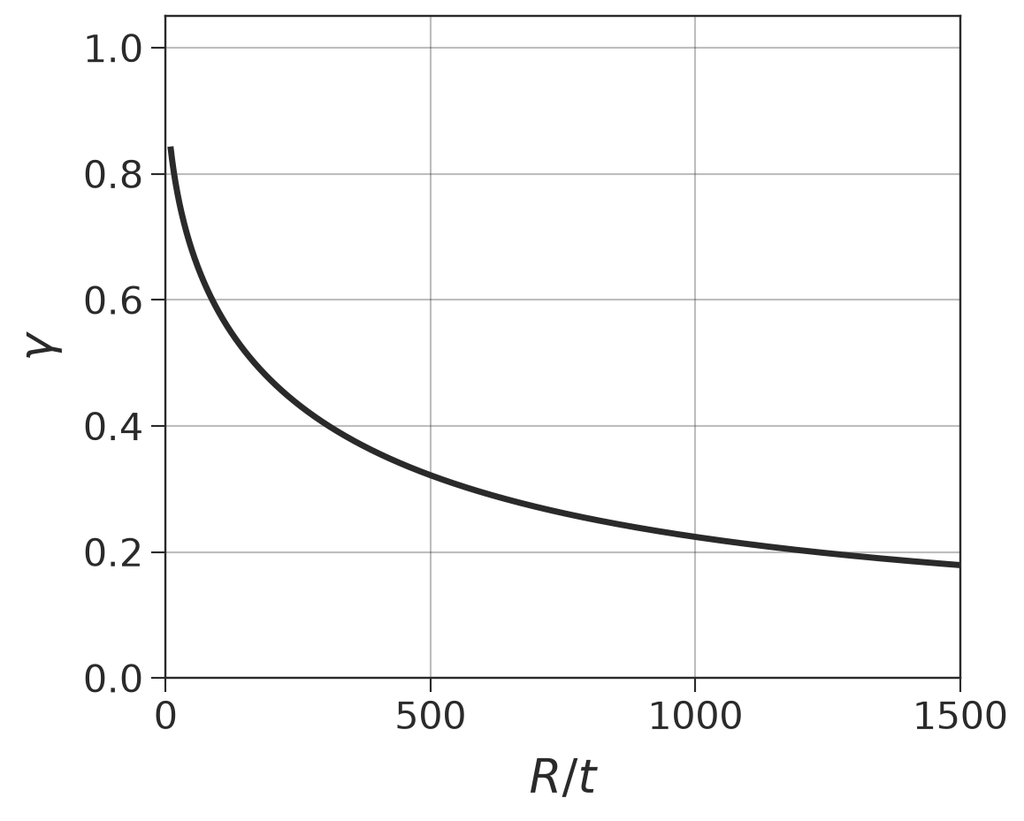

## Correções semi-empíricas

- Correção para R/t = 500
- Diferentes razões R/t

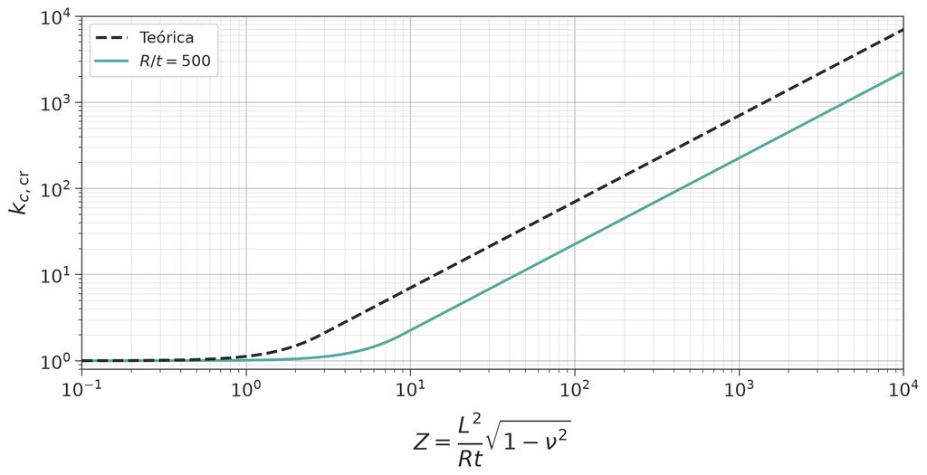

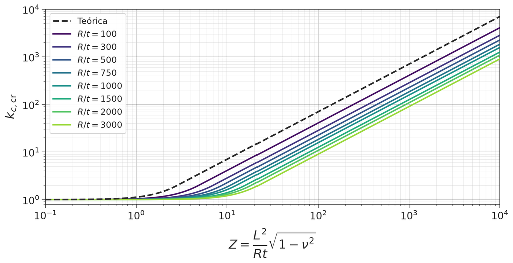